# Homework 6

STA 360: Assignment 6, Fall 2020

Due Monday October 12, 5 PM Standard Eastern Time

# Question 2

Part 1

1. The below code was taken from Professors Rebecca C. Steort’s provided template code.

```r
knitr::opts_chunk$set(cache=TRUE)
library(xtable)

# Samples from a truncated gamma with
# truncation (t, infty), shape a, and rate b
# Input: t,a,b
# Output: truncated Gamma(a,b)
sampleTrunGamma <- function(t, a, b){
  # This function samples from a truncated gamma with
  # truncation (t, infty), shape a, and rate b
  p0 <- pgamma(t, shape = a, rate = b)
  x <- runif(1, min = p0, max = 1)
  y <- qgamma(x, shape = a, rate = b)
  return(y)
}

# Gibbs sampler for censored data
# Inputs:
  # this function is a Gibbs sampler
  # z is the fully observe data
  # c is censored data
  # n.iter is number of iterations
  # init.theta and init.miss are initial values for sampler
  # r,a, and b are parameters
  # burnin is number of iterations to use as burnin
# Output: theta, z
sampleGibbs <- function(z, c, n.iter, init.theta, init.miss, r, a, b, burnin = 1){

  z.sum <- sum(z)
  m <- length(c)
  n <- length(z) + m
  miss.vals <- init.miss
  res <- matrix(NA, nrow = n.iter, ncol = 1 + m)
  for (i in 1:n.iter){
    var.sum <- z.sum + sum(miss.vals)
    theta <- rgamma(1, shape = a + n*r, rate = b + var.sum)
    miss.vals <- sapply(c, function(x) {sampleTrunGamma(x, r, theta)})
    res[i,] <- c(theta, miss.vals)
  }
  return(res[burnin:n.iter,])
}
# set parameter values
r <- 10
a <- 1
b <- 1
# input data
z <- c(3.4,2.9,1.4,3.2,1.8,4.6,2.8)
c <- c(1.2,1.7,2.0,1.4,0.6)
n.iter <- 200
init.theta <- 1
init.missing <- rgamma(length(c), shape = r, rate = init.theta)
# run sampler
res <- sampleGibbs(z, c, n.iter, init.theta, init.missing, r, a, b)
# get running averages
run.avg <- apply(res, 2, cumsum)/(1:n.iter)
```

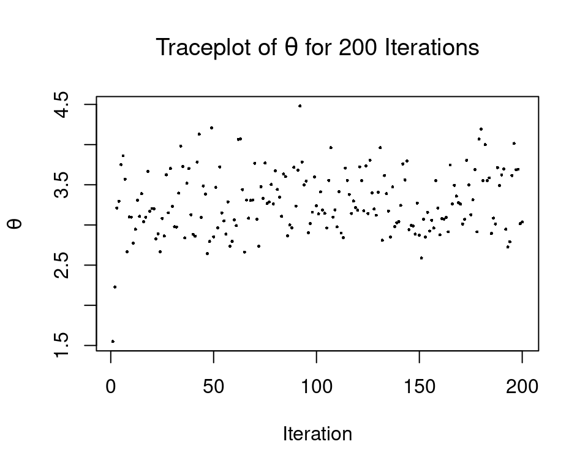

```r
#Create Traceplot for Theta
plot(1:n.iter, res[,1], pch = 16, cex = .35,
     xlab = "Iteration", ylab = expression(theta),
     main = expression(paste("Traceplot of ", theta," for 200 Iterations")))
```

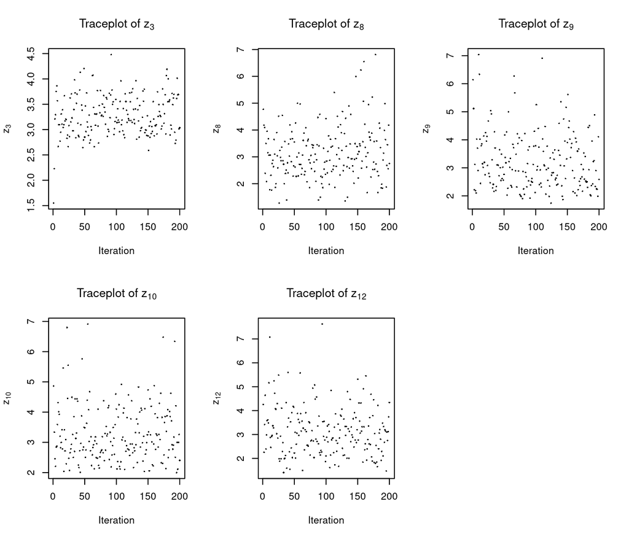

```r
#Create Traceplots for Censored Values
missing.index <- c(3,8,9,10,12)
par(mfrow=c(2,3))
for (ind in missing.index){
  x.lab <- bquote(z[.(ind)])
  plot(1:n.iter, res[,which(missing.index == ind)], pch = 16, cex = .35,
       xlab = "Iteration", ylab = x.lab,
       main = bquote(paste("Traceplot of ", .(x.lab))))
}
plot.new()
```

[figure not shown]

Running average plot of theta

```r
#Create Running Average Plot for Theta
plot(1:n.iter, run.avg[,1], type = "l",
     xlab = "Iteration", ylab = expression(theta),
     main = expression(paste("Running Average Plot of ", theta, " for 10,000 iterations")))
```

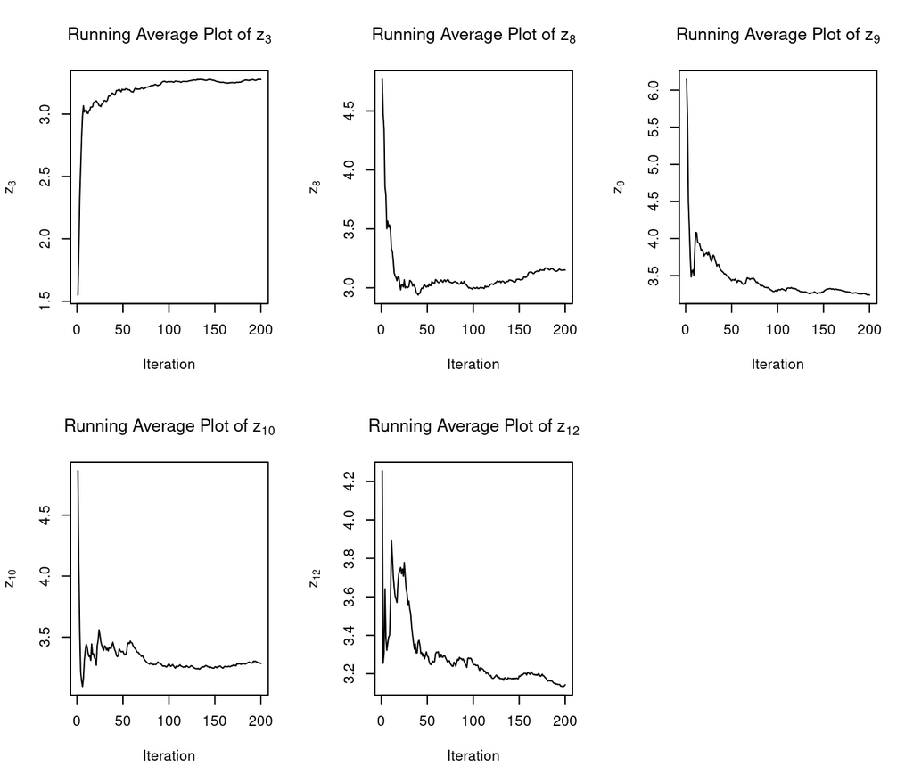

```r
#Create Running Average plots for Censored Values
par(mfrow=c(2,3))
missing.index <- c(3,8,9,10,12)
for (ind in missing.index){
  x.lab <- bquote(z[.(ind)])
  plot(1:n.iter, run.avg[,which(missing.index == ind)], type = "l",
       xlab = "Iteration", ylab = x.lab,
       main = bquote(paste("Running Average Plot of ", .(x.lab))))
}
plot.new()
```

From the plots above, we can see that the plots show clear variation among values which means the sampler is having mixing issues. If you look at the traceplots, there’s very visible variation in the values for theta and z3, 8,9,10,12 and the running average plots don’t appear to be steady (like a straight line), instead we can see bumps and obvious variation. This means we have not ran our sampler long enough.

```r
n.iter2 <- 10000
init.missing2 <- rgamma(length(c), shape = r, rate = init.theta)
# run sampler
res2 <- sampleGibbs(z, c, n.iter2, init.theta, init.missing2, r, a, b)
# get running averages
run.avg2 <- apply(res2, 2, cumsum)/(1:n.iter2)
```

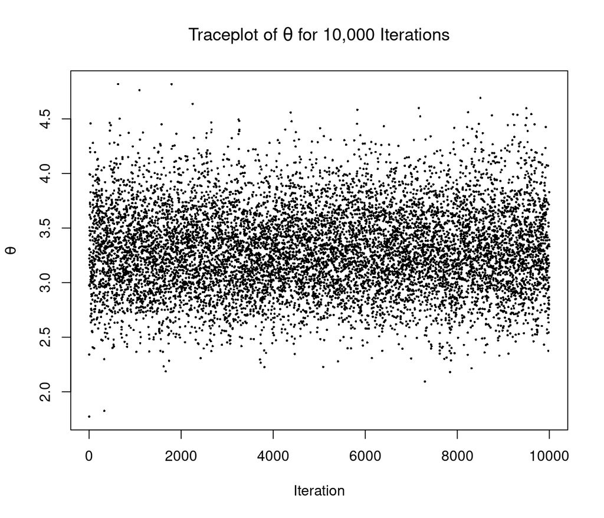

Traceplot of theta

```r
#Create Traceplot for Theta
plot(1:n.iter2, res2[,1], pch = 16, cex = .35,
     xlab = "Iteration", ylab = expression(theta),
     main = expression(paste("Traceplot of ", theta," for 10,000 Iterations")))
```

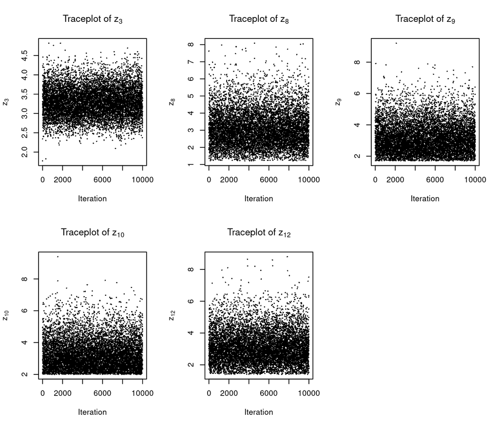

```r
#Create Traceplots for Censored Values
missing.index <- c(3,8,9,10,12)
par(mfrow=c(2,3))
for (ind in missing.index){
  x.lab <- bquote(z[.(ind)])
  plot(1:n.iter2, res2[,which(missing.index == ind)], pch = 16, cex = .35,
       xlab = "Iteration", ylab = x.lab,
       main = bquote(paste("Traceplot of ", .(x.lab))))
}
plot.new()
```

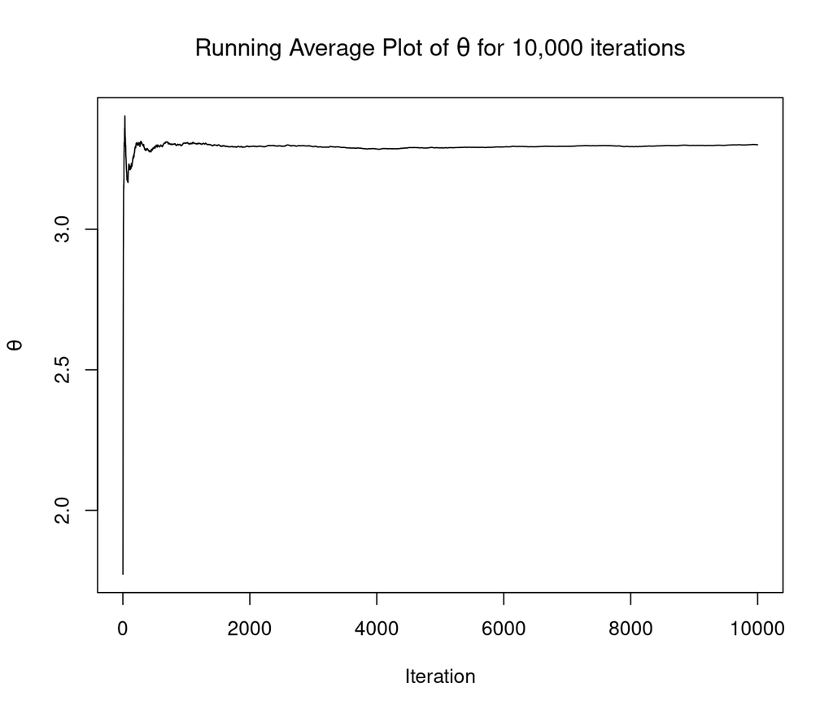

Running average plot of theta

```r
#Create Running Average Plot for Theta
plot(1:n.iter2, run.avg2[,1], type = "l",
     xlab = "Iteration", ylab = expression(theta),
     main = expression(paste("Running Average Plot of ", theta, " for 10,000 iterations")))
```

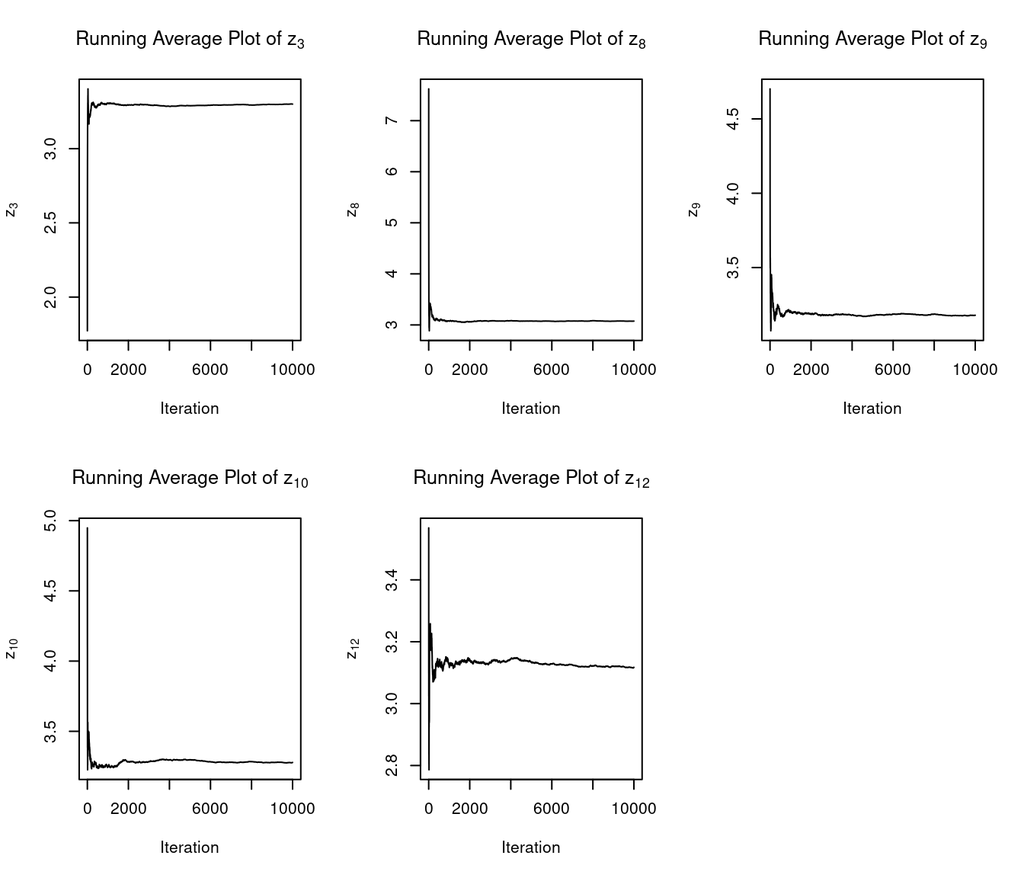

```r
#Create Running Average plots for Censored Values
par(mfrow=c(2,3))
missing.index <- c(3,8,9,10,12)
for (ind in missing.index){
  x.lab <- bquote(z[.(ind)])
  plot(1:n.iter2, run.avg2[,which(missing.index == ind)], type = "l",
       xlab = "Iteration", ylab = x.lab,
       main = bquote(paste("Running Average Plot of ", .(x.lab))))
}
plot.new()
```

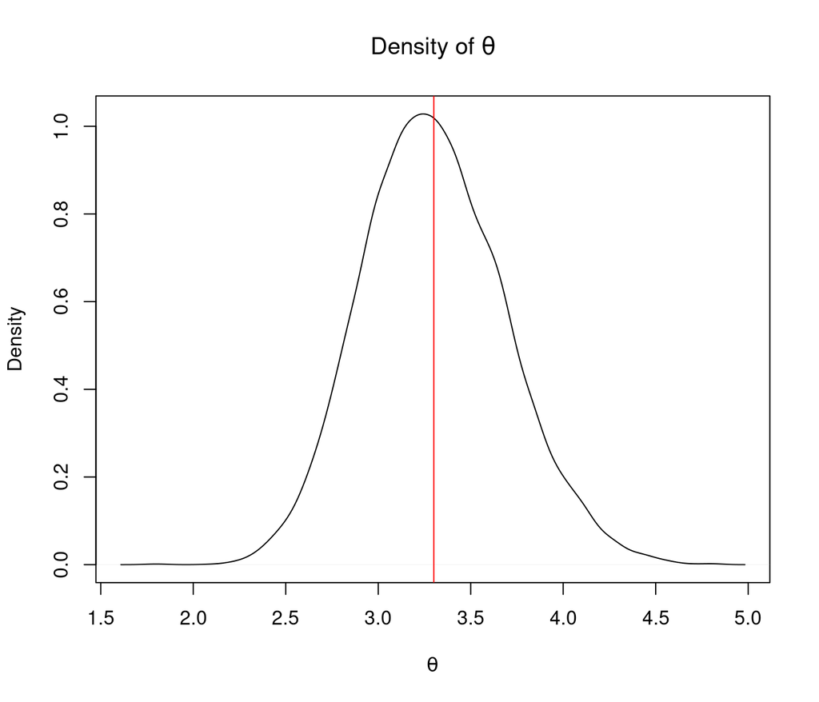

Estimated posterior density of theta

```r
# density plots
plot(density(res2[,1]), xlab = expression(theta),
     main = expression(paste("Density of ", theta)))
abline(v = mean(res2[,1]), col = "red")
```

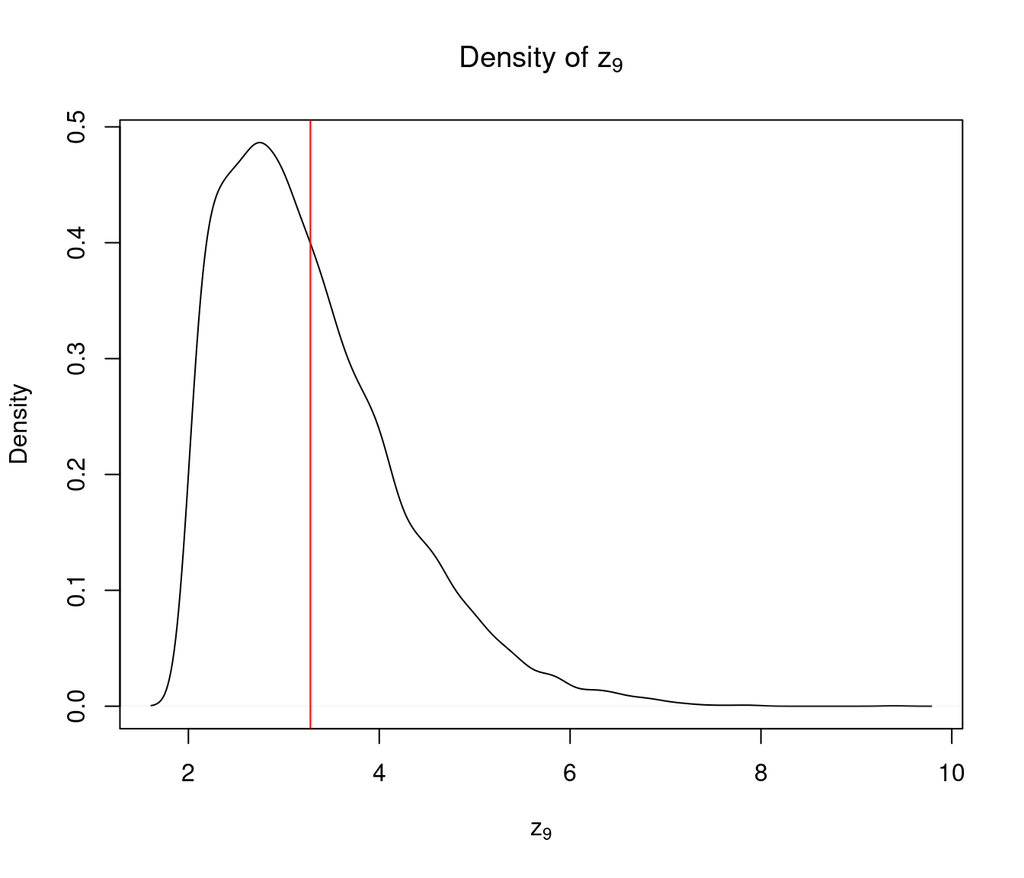

Estimated posterior density of $z_9$ (posterior mean in red).

```r
plot(density(res2[,4]), xlab = expression(z[9]),
     main = expression(paste("Density of ", z[9])))
abline(v = mean(res2[,4]), col = "red")
```

From the density plot of theta, we can see that the rate parameter for the life time distribution is around 3.25. This means the average life expectancy (r/theta with r being 10) is around 3 years (10/3.25) and the variance (r/theta^2) being around 1 (10/10.5625). For the density plot of z9, we can see the the value of z9 with the highest density is around 3. This means, we predict that patient 9 who lived at least 2 years after the operation, most likely, to have made it to 3 years. Because we don’t know what actually happened to patient 2, we use our latent variable z9 to impute a value instead. And the density plot of z9 reveals that a value around 3 is far more likely than values such as 6 or 8 years.

```r
b2 <- 100
# run sampler
res3 <- sampleGibbs(z, c, n.iter2, init.theta, init.missing, r, a, b2)
```

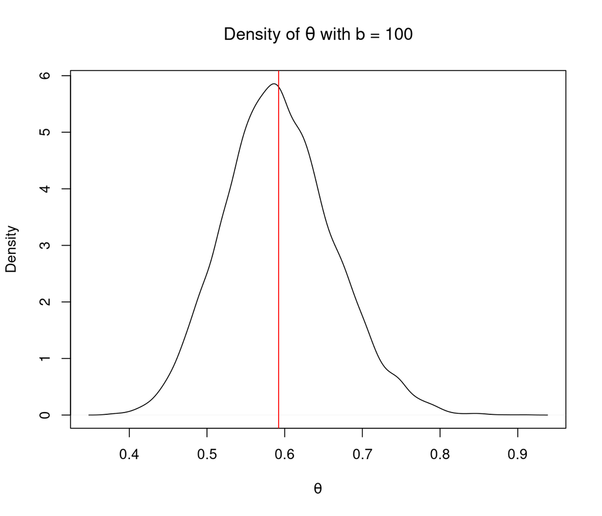

Estimated posterior density of theta

```r
# density plots
plot(density(res3[,1]), xlab = expression(theta),
     main = expression(paste("Density of ", theta, " with b = 100")))
abline(v = mean(res3[,1]), col = "red")
```

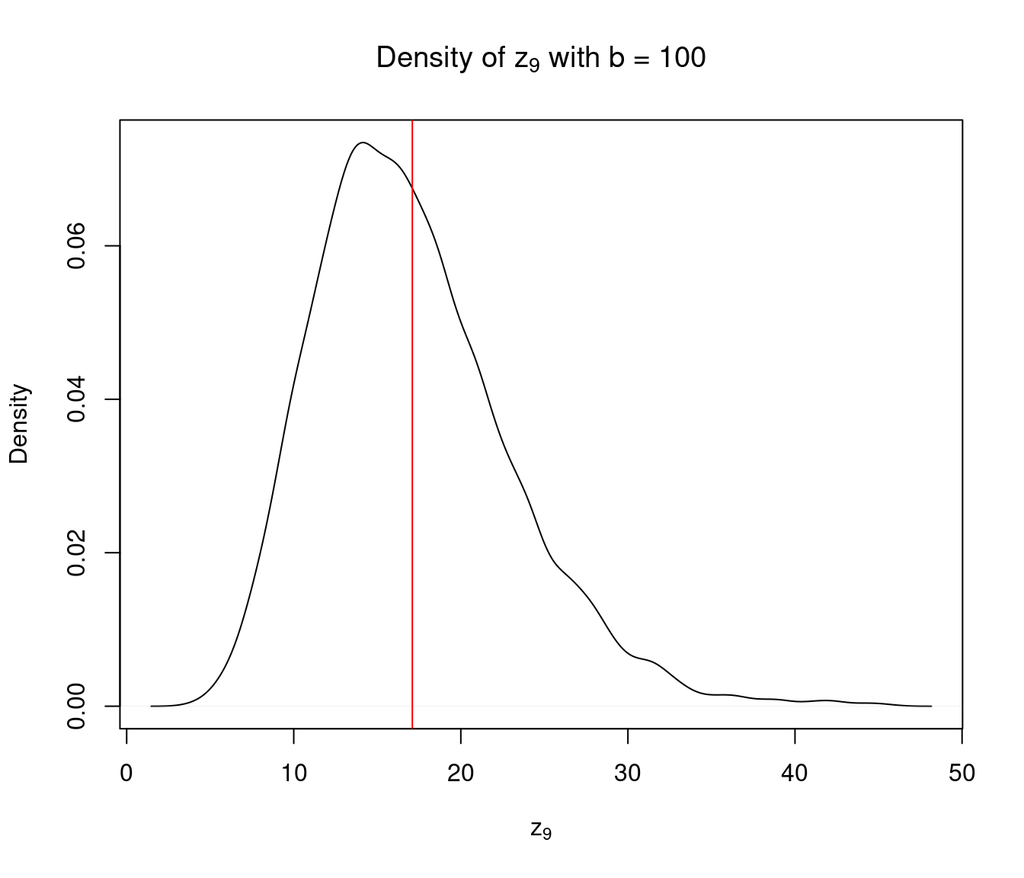

Estimated posterior density of $z_9$ (posterior mean in red).

```r
plot(density(res3[,4]), xlab = expression(z[9]),
     main = expression(paste("Density of ", z[9], " with b = 100")))
abline(v = mean(res3[,4]), col = "red")
```

```r
a2 <- 100
# run sampler
res4 <- sampleGibbs(z, c, n.iter2, init.theta, init.missing, r, a2, b)
```

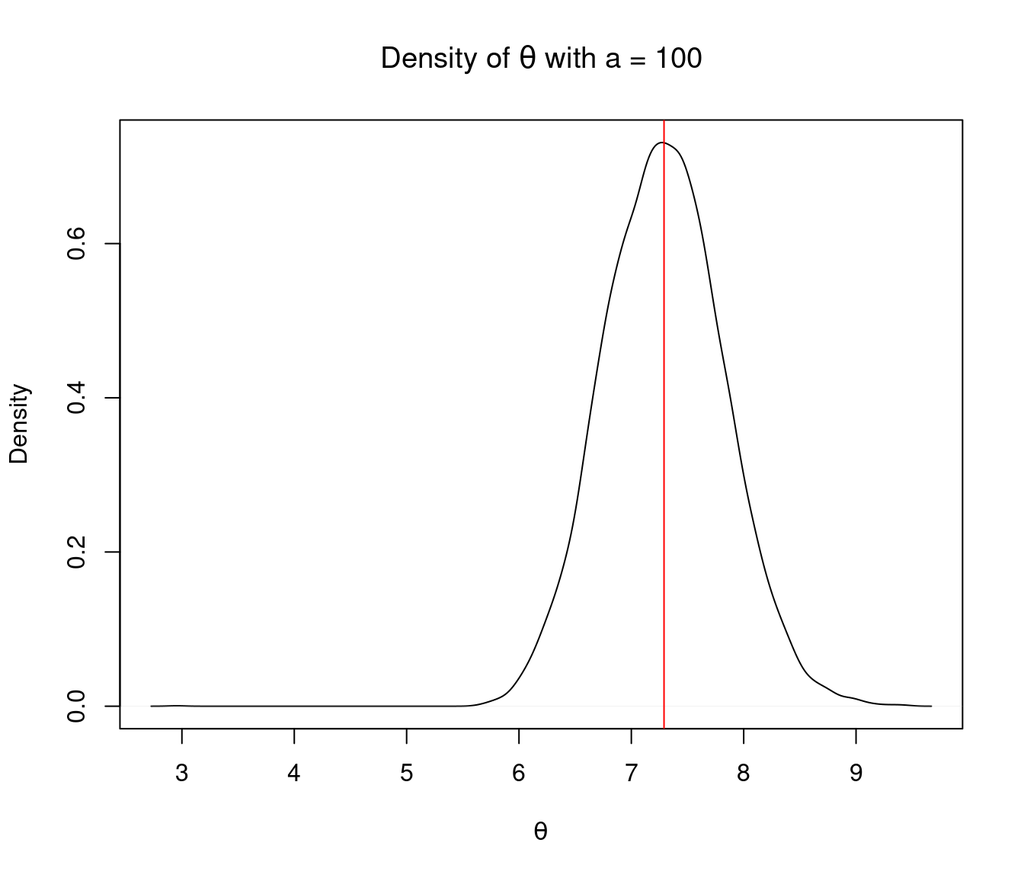

Estimated posterior density of theta

```r
# density plots
plot(density(res4[,1]), xlab = expression(theta),
     main = expression(paste("Density of ", theta, " with a = 100")))
abline(v = mean(res4[,1]), col = "red")
```

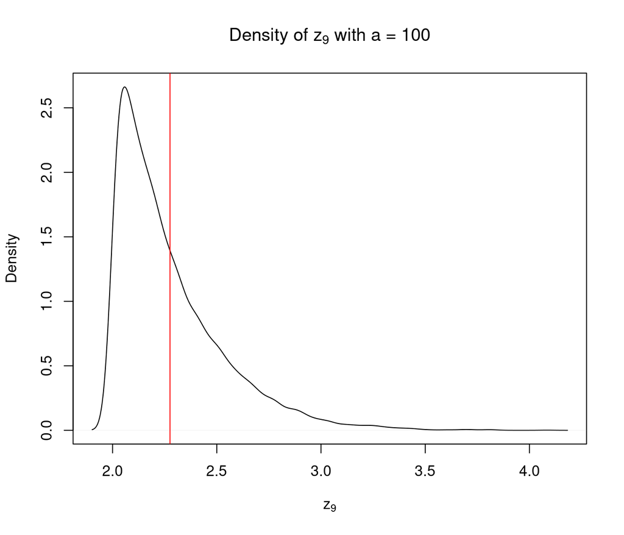

Estimated posterior density of $z_9$ (posterior mean in red).

```r
plot(density(res4[,4]), xlab = expression(z[9]),
     main = expression(paste("Density of ", z[9], " with a = 100")))
abline(v = mean(res4[,4]), col = "red")
```

When b (or the rate of our prior) is increased, we can see that the mean value of theta (the rate used in our truncated gamma) decreases to around a value of 0.6. When the rate decreases for the truncated gamma, we can see that the mean value of z9 increases to around 17. When you increase the value of a or the shape of our prior on theta, we see that the mean value of theta increases to around 7. When the rate increases for the truncated gamma, we see the mean value for z9 decrease to around 2.2. By changing a,b which in turn changes the value of theta, which is used to produce our truncated gamma we sample from for our censored values, our imputed values are affected.